# R Notebook

## 0. Introduction

The purpose of this analysis is to determine which gene sets from [MSigDB](http://software.broadinstitute.org/gsea/msigdb/index.jsp) are most enriched in the genes we previously predicted to contain IREs. This is important as we wanted to see the biological relevance of the IRE-containing genes, and also their overlap in existing gene sets.

The approach is as follows:

- Load in relevant gene set collections from MSigDB.
- Get them into a format suitable for performing Fisher’s exact test to test whether they are enriched for IRE-containing genes.
- Results displayed on a bar chart.

The motivation for doing this analysis comes from an interesting observation using the naive approach of searching MSigDB for all gene sets with **iron** or **heme** in their name and seeing the overlap in genes between these gene sets and the IRE-containing genesets we identified.

```r
ironSets <- list(
  c5_GO_2_IRON_2_SULFUR_CLUSTER_BINDING = c5_mapped$GO_2_IRON_2_SULFUR_CLUSTER_BINDING,
  c5_GO_4_IRON_4_SULFUR_CLUSTER_BINDING = c5_mapped$GO_4_IRON_4_SULFUR_CLUSTER_BINDING,
  c5_GO_CELLULAR_IRON_ION_HOMEOSTASIS = c5_mapped$GO_CELLULAR_IRON_ION_HOMEOSTASIS,
  c5_GO_HEME_METABOLIC_PROCESS = c5_mapped$GO_HEME_METABOLIC_PROCESS,
  c5_GO_HEME_BIOSYNTHETIC_PROCESS = c5_mapped$GO_HEME_BIOSYNTHETIC_PROCESS,
  c5_GO_HEMOGLOBIN_COMPLEX = c5_mapped$GO_HEMOGLOBIN_COMPLEX,
  c5_GO_IRON_COORDINATION_ENTITY_TRANSPORT = c5_mapped$GO_IRON_COORDINATION_ENTITY_TRANSPORT,
  c5_GO_IRON_ION_BINDING = c5_mapped$GO_IRON_ION_BINDING,
  c5_GO_IRON_ION_HOMEOSTASIS = c5_mapped$GO_IRON_ION_HOMEOSTASIS,
  c5_GO_IRON_ION_IMPORT = c5_mapped$GO_IRON_ION_IMPORT,
  c5_GO_IRON_ION_TRANSPORT = c5_mapped$GO_IRON_ION_TRANSPORT,
  c5_GO_OXIDOREDUCTASE_ACTIVITY_ACTING_ON_A_HEME_GROUP_OF_DONORS = c5_mapped$GO_OXIDOREDUCTASE_ACTIVITY_ACTING_ON_A_HEME_GROUP_OF_DONORS,
  c5_GO_RESPONSE_TO_IRON_ION = c5_mapped$GO_RESPONSE_TO_IRON_ION,
  h_HEME_METABOLISM = h_mapped$HALLMARK_HEME_METABOLISM,
  c2_REACTOME_IRON_UPTAKE_AND_TRANSPORT = c2_mapped$REACTOME_IRON_UPTAKE_AND_TRANSPORT
)
ironSets_idx <- ids2indices(ironSets, rownames(v))
head(ironSets,2)
```

```
$c5_GO_2_IRON_2_SULFUR_CLUSTER_BINDING
 [1] "ENSDARG00000062780" "ENSDARG00000079516" "ENSDARG00000052703" "ENSDARG00000013044" "ENSDARG00000007745" "ENSDARG00000038154"
 [7] "ENSDARG00000051956" "ENSDARG00000052190" "ENSDARG00000003462" "ENSDARG00000045733" "ENSDARG00000043665" "ENSDARG00000026582"
[13] "ENSDARG00000035596" "ENSDARG00000020054" "ENSDARG00000074356" "ENSDARG00000028546" "ENSDARG00000092713" "ENSDARG00000058725"
[19] "ENSDARG00000042159" "ENSDARG00000055240"

$c5_GO_4_IRON_4_SULFUR_CLUSTER_BINDING
 [1] "ENSDARG00000055472" "ENSDARG00000021466" "ENSDARG00000074552" "ENSDARG00000010267" "ENSDARG00000086853" "ENSDARG00000042727"
 [7] "ENSDARG00000062216" "ENSDARG00000027689" "ENSDARG00000026376" "ENSDARG00000036438" "ENSDARG00000074889" "ENSDARG00000004952"
[13] "ENSDARG00000035074" "ENSDARG00000052721" "ENSDARG00000051986" "ENSDARG00000092713" "ENSDARG00000077698" "ENSDARG00000021985"
[19] "ENSDARG00000104848" "ENSDARG00000110572" "ENSDARG00000042881" "ENSDARG00000004517" "ENSDARG00000062987" "ENSDARG00000054821"
[25] "ENSDARG00000038154" "ENSDARG00000051956" "ENSDARG00000011072" "ENSDARG00000055653" "ENSDARG00000058801" "ENSDARG00000007526"
[31] "ENSDARG00000026582" "ENSDARG00000035596" "ENSDARG00000058533" "ENSDARG00000022845" "ENSDARG00000038834" "ENSDARG00000028546"
[37] "ENSDARG00000045308" "ENSDARG00000007294" "ENSDARG00000078479" "ENSDARG00000074410"
```

```r
head(ironSets_idx,2)
```

```
$c5_GO_2_IRON_2_SULFUR_CLUSTER_BINDING
 [1]   392  1152  2009  3261  4076  4317  5266  5874  6672  7030  7494  7669  7725  7829  9213 10372 11992 13712

$c5_GO_4_IRON_4_SULFUR_CLUSTER_BINDING
 [1]   582   666  1075  1117  1553  1678  3513  3591  3669  4053  4076  4219  4317  5167  5266  5472  5874  5996  6790  6835  7375  7669
[23]  7675  7834  8248  8392  8444  9159  9231 10196 10441 12008 12054 12192 13108 13371 14022 18609
```

We used a gene set enrichment analysis approach to test for whether these iron-related gene sets were enriched in our DE results.

```r
source(here("R","GSEA","combinedGSEA.R"))

gseaResults_ironSets <- combinedGSEA(v, ironSets_idx, design, contrasts)
# gseaResults_ironSets %>% saveRDS(here("R","GSEA","results","gseaResults_ironSets.rds"))
# gseaResults_ironSets %>% write.xlsx(here("R","GSEA","results","gseaResults_ironSets.xlsx"))
```

```r
gseaResults_ironSets$combTest$normoxia_6mth_mutant_vs_wt
```

[output not shown]

## 1. Relevant gene sets

We will be using the following gene set collections from **MSigDB**:

- **Hallmark gene sets** (**H**) are coherently expressed signatures derived by aggregating many MSigDB gene sets to represent well-defined biological states or processes.
- **Curated gene sets** (**C2**) are from online pathway databases, publications in PubMed, and knowledge of domain experts.
- **Motif gene sets** (**C3**) are based on conserved cis-regulatory motifs from a comparative analysis of the human, mouse, rat, and dog genomes.
- **Gene ontology gene sets** (**C5**) consist of genes annotated by the same GO terms.

The gene set collections mapped to zebrafish Ensembl IDs have been pre-loaded for this analysis. Each collection is a named list of gene sets, with each gene set containing Ensembl IDs of genes in that set. We will convert all lists into list column structures used in the *tibble* package.

```r
h_tib <- h_mapped %>% tibble %>% set_colnames(c("ids")) %>% mutate(geneset = names(h_mapped), source = "h")
c2_tib <- c2_mapped %>% tibble %>% set_colnames(c("ids")) %>% mutate(geneset = names(c2_mapped), source = "c2")
c3_tib <- c3_mapped %>% tibble %>% set_colnames(c("ids")) %>% mutate(geneset = names(c3_mapped), source = "c3")
c5_tib <- c5_mapped %>% tibble %>% set_colnames(c("ids")) %>% mutate(geneset = names(c5_mapped), source = "c5")
gs <- bind_rows(h_tib, c2_tib, c3_tib, c5_tib)
gs
```

| ids | geneset | source |
| --- | --- | --- |
|  | HALLMARK_TNFA_SIGNALING_VIA_NFKB | h |
|  | HALLMARK_HYPOXIA | h |
|  | HALLMARK_CHOLESTEROL_HOMEOSTASIS | h |
|  | HALLMARK_MITOTIC_SPINDLE | h |
|  | HALLMARK_WNT_BETA_CATENIN_SIGNALING | h |
|  | HALLMARK_TGF_BETA_SIGNALING | h |
|  | HALLMARK_IL6_JAK_STAT3_SIGNALING | h |
|  | HALLMARK_DNA_REPAIR | h |
|  | HALLMARK_G2M_CHECKPOINT | h |
|  | HALLMARK_APOPTOSIS | h |

[output cut: 990 more lines]

We previously loaded the `ireGenes` R object, which has the following structure:

```r
ireGenes%>%str
```

```
List of 4
 $ ire3_all: chr [1:1207] "ENSDARG00000102878" "ENSDARG00000070477" "ENSDARG00000006038" "ENSDARG00000063481" ...
 $ ire5_all: chr [1:393] "ENSDARG00000045911" "ENSDARG00000017386" "ENSDARG00000045886" "ENSDARG00000015921" ...
 $ ire3_hq : chr [1:106] "ENSDARG00000074223" "ENSDARG00000024874" "ENSDARG00000110878" "ENSDARG00000089296" ...
 $ ire5_hq : chr [1:49] "ENSDARG00000045911" "ENSDARG00000101351" "ENSDARG00000100006" "ENSDARG00000015551" ...
```

```r
allIREGenes <- c(ireGenes$ire3_all, ireGenes$ire5_all)
allIREGenes %>% head
```

```
[1] "ENSDARG00000102878" "ENSDARG00000070477" "ENSDARG00000006038" "ENSDARG00000063481" "ENSDARG00000045842" "ENSDARG00000095332"
```

## 2. Compute gene overlap with IRE genesets

We wish to see the overlap between the genesets in `gs` with the `ireGenes` (including 3’ and 5’ IRE genes), as well as separately, with the 3’ IRE genes and 5’ IRE genes. We will add this information into the `gs` tibble.

```r
gs %<>% rowwise() %>% mutate(
  n = length(ids),  # Number of genes in the geneset

  n_with_ire = sum(ids %in% allIREGenes),  # Number of genes in the gene set which have 3' or 5' predicted IREs
  n_without_ire = (n - n_with_ire),
  universe_with_ire = sum(rownames(v) %in% allIREGenes & !(rownames(v) %in% ids)),
  universe_without_ire = (length(rownames(v)) - universe_with_ire),

  n_with_ire3 = sum(ids %in% ireGenes$ire3_all),  # Number of genes in the gene set which have 3' predicted IREs
  n_without_ire3= (n - n_with_ire),
  universe_with_ire3 = sum(rownames(v) %in% ireGenes$ire3_all & !(rownames(v) %in% ids)),
  universe_without_ire3 = (length(rownames(v)) - universe_with_ire),

  n_with_ire5 = sum(ids %in% ireGenes$ire5_all),  # Number of genes in the gene set which have 5' predicted IREs
  n_without_ire5= (n - n_with_ire),
  universe_with_ire5 = sum(rownames(v) %in% ireGenes$ire5_all & !(rownames(v) %in% ids)),
  universe_without_ire5 = (length(rownames(v)) - universe_with_ire)
) %>% ungroup()
gs
```

| ids | geneset | source | n | n_with_ire | n_without_ire | universe_with_ire | universe_without_ire | n_with_ire3 | n_without_ire3 | universe_with_ire3 | universe_without_ire3 | n_with_ire5 | n_without_ire5 | universe_with_ire5 | universe_without_ire5 |
| --- | --- | --- | --- | --- | --- | --- | --- | --- | --- | --- | --- | --- | --- | --- | --- |
|  | HALLMARK_TNFA_SIGNALING_VIA_NFKB | h | 258 | 15 | 243 | 1433 | 18274 | 9 | 243 | 1119 | 18274 | 6 | 243 | 344 | 18274 |
|  | HALLMARK_HYPOXIA | h | 260 | 19 | 241 | 1430 | 18277 | 14 | 241 | 1115 | 18277 | 7 | 241 | 343 | 18277 |
|  | HALLMARK_CHOLESTEROL_HOMEOSTASIS | h | 91 | 5 | 86 | 1443 | 18264 | 4 | 86 | 1124 | 18264 | 2 | 86 | 348 | 18264 |
|  | HALLMARK_MITOTIC_SPINDLE | h | 257 | 24 | 233 | 1425 | 18282 | 20 | 233 | 1108 | 18282 | 4 | 233 | 347 | 18282 |
|  | HALLMARK_WNT_BETA_CATENIN_SIGNALING | h | 53 | 2 | 51 | 1446 | 18261 | 2 | 51 | 1126 | 18261 | 0 | 51 | 350 | 18261 |
|  | HALLMARK_TGF_BETA_SIGNALING | h | 68 | 6 | 62 | 1442 | 18265 | 6 | 62 | 1122 | 18265 | 0 | 62 | 350 | 18265 |
|  | HALLMARK_IL6_JAK_STAT3_SIGNALING | h | 106 | 9 | 97 | 1440 | 18267 | 8 | 97 | 1121 | 18267 | 1 | 97 | 349 | 18267 |
|  | HALLMARK_DNA_REPAIR | h | 166 | 13 | 153 | 1435 | 18272 | 9 | 153 | 1119 | 18272 | 5 | 153 | 345 | 18272 |
|  | HALLMARK_G2M_CHECKPOINT | h | 253 | 22 | 231 | 1426 | 18281 | 17 | 231 | 1111 | 18281 | 5 | 231 | 345 | 18281 |
|  | HALLMARK_APOPTOSIS | h | 199 | 13 | 186 | 1436 | 18271 | 11 | 186 | 1118 | 18271 | 3 | 186 | 347 | 18271 |

[output cut: 990 more lines]

## 3. Contingency tables

Create contingency table for each gene set. We will store this in a list of matrices `gs_mat`. The 3’ and 5’ contingency matrices are stored in `gs_mat3` and `gs_mat5`.

```r
gs_mat <- gs %>%
  dplyr::select(n_with_ire,
                n_without_ire,
                universe_with_ire,
                universe_without_ire) %>%
  apply(X = ., MARGIN = 1, FUN = function(x){
    x %>%
      matrix(2,2) %>%
      t %>%
      list()
  }) %>% set_names(gs$geneset) %>%
  lapply(function(x){
    x %>% .[[1]]
  })

gs_mat3 <- gs %>%
  dplyr::select(n_with_ire3,
                n_without_ire3,
                universe_with_ire3,
                universe_without_ire3) %>%
  apply(X = ., MARGIN = 1, FUN = function(x){
    x %>%
      matrix(2,2) %>%
      t %>%
      list()
  }) %>% set_names(gs$geneset) %>%
  lapply(function(x){
    x %>% .[[1]]
  })

gs_mat5 <- gs %>%
  dplyr::select(n_with_ire5,
                n_without_ire5,
                universe_with_ire5,
                universe_without_ire5) %>%
  apply(X = ., MARGIN = 1, FUN = function(x){
    x %>%
      matrix(2,2) %>%
      t %>%
      list()
  }) %>% set_names(gs$geneset) %>%
  lapply(function(x){
    x %>% .[[1]]
  })
```

```r
gs_mat[1:3]
```

```
$HALLMARK_TNFA_SIGNALING_VIA_NFKB
     [,1]  [,2]
[1,]   15   243
[2,] 1433 18274

$HALLMARK_HYPOXIA
     [,1]  [,2]
[1,]   19   241
[2,] 1430 18277

$HALLMARK_CHOLESTEROL_HOMEOSTASIS
     [,1]  [,2]
[1,]    5    86
[2,] 1443 18264
```

```r
gs_mat3[1:3]
```

```
$HALLMARK_TNFA_SIGNALING_VIA_NFKB
     [,1]  [,2]
[1,]    9   243
[2,] 1119 18274

$HALLMARK_HYPOXIA
     [,1]  [,2]
[1,]   14   241
[2,] 1115 18277

$HALLMARK_CHOLESTEROL_HOMEOSTASIS
     [,1]  [,2]
[1,]    4    86
[2,] 1124 18264
```

```r
gs_mat5[1:3]
```

```
$HALLMARK_TNFA_SIGNALING_VIA_NFKB
     [,1]  [,2]
[1,]    6   243
[2,]  344 18274

$HALLMARK_HYPOXIA
     [,1]  [,2]
[1,]    7   241
[2,]  343 18277

$HALLMARK_CHOLESTEROL_HOMEOSTASIS
     [,1]  [,2]
[1,]    2    86
[2,]  348 18264
```

## 4. Fisher’s exact test

On each contingency table, we will run Fisher’s exact test. We then apply FDR correction to adjust the raw *p*-values for multiple testing.

```r
fisher_res <- gs_mat %>% lapply(function(x){
  x %>% fisher.test()
})

fisher_res3 <- gs_mat3 %>% lapply(function(x){
  x %>% fisher.test()
})

fisher_res5 <- gs_mat5 %>% lapply(function(x){
  x %>% fisher.test()
})

fisher_res_p <- fisher_res %>% lapply(function(x){x$p.value})
fisher_res_p3 <- fisher_res3 %>% lapply(function(x){x$p.value})
fisher_res_p5 <- fisher_res5 %>% lapply(function(x){x$p.value})

gs %<>%
  mutate(fisher_p = fisher_res_p%>%unlist%>%unname,
         fisher_p_3 = fisher_res_p3%>%unlist%>%unname,
         fisher_p_5 = fisher_res_p5%>%unlist%>%unname) %>%
  mutate(fdr = p.adjust(fisher_p, "fdr"),
         fdr_3 = p.adjust(fisher_p_3, "fdr"),
         fdr_5 = p.adjust(fisher_p_5, "fdr"))
```

## 5. Calculate Expected and Observed

For each gene set, we will calculate the number of genes **expected** to have IREs (based on the background proportion) and **observed** value. This information will be added to the `gs` object.

```r
gs %<>% rowwise() %>% mutate(
  exp_allIRE = (universe_with_ire / universe_without_ire)*n_without_ire,
  obs_allIRE = n_with_ire,
  obs_greater_than_exp_allIRE = obs_allIRE > exp_allIRE,

  exp_ire3 = (universe_with_ire3 / universe_without_ire3)*n_without_ire3,
  obs_ire3 = n_with_ire3,
  obs_greater_than_exp_ire3 = obs_ire3 > exp_ire3,

  exp_ire5 = (universe_with_ire5 / universe_without_ire5)*n_without_ire5,
  obs_ire5 = n_with_ire5,
  obs_greater_than_exp_ire5 = obs_ire5 > exp_ire5
)
```

```r
gs %>%
  dplyr::select(geneset, contains("exp"), starts_with("obs"), )
```

```
Source: local data frame [11,534 x 10]
Groups: <by row>

# A tibble: 11,534 x 10
   geneset                         exp_allIRE obs_greater_than_exp_all… exp_ire3 obs_greater_than_exp_i… exp_ire5 obs_greater_than_exp_i… obs_allIRE obs_ire3 obs_ire5
   <chr>                                <dbl> <lgl>                        <dbl> <lgl>                      <dbl> <lgl>                        <int>    <int>    <int>
 1 HALLMARK_TNFA_SIGNALING_VIA_NF…      19.1  FALSE                        14.9  FALSE                      4.57  TRUE                            15        9        6
 2 HALLMARK_HYPOXIA                     18.9  TRUE                         14.7  FALSE                      4.52  TRUE                            19       14        7
 3 HALLMARK_CHOLESTEROL_HOMEOSTAS…       6.79 FALSE                         5.29 FALSE                      1.64  TRUE                             5        4        2
 4 HALLMARK_MITOTIC_SPINDLE             18.2  TRUE                         14.1  TRUE                       4.42  FALSE                           24       20        4
 5 HALLMARK_WNT_BETA_CATENIN_SIGN…       4.04 FALSE                         3.14 FALSE                      0.977 FALSE                            2        2        0
 6 HALLMARK_TGF_BETA_SIGNALING           4.89 TRUE                          3.81 TRUE                       1.19  FALSE                            6        6        0
 7 HALLMARK_IL6_JAK_STAT3_SIGNALI…       7.65 TRUE                          5.95 TRUE                       1.85  FALSE                            9        8        1
 8 HALLMARK_DNA_REPAIR                  12.0  TRUE                          9.37 FALSE                      2.89  TRUE                            13        9        5
 9 HALLMARK_G2M_CHECKPOINT              18.0  TRUE                         14.0  TRUE                       4.36  TRUE                            22       17        5
10 HALLMARK_APOPTOSIS                   14.6  FALSE                        11.4  FALSE                      3.53  FALSE                           13       11        3
# … with 11,524 more rows
```

## 6. Results

The following table shows the top 50 gene sets enriched in IRE genesets, ranked by Fisher’s exact test *p*-values:

```r
gs %>% ungroup() %>%
  arrange(fisher_p) %>%
  dplyr::select(geneset, contains("fdr"), n_with_ire, n, starts_with("obs_greater")) %>%
  head(50)
```

| geneset | fdr | fdr_3 | fdr_5 | n_with_ire | n | obs_greater_than_exp_allIRE | obs_greater_than_exp_ire3 | obs_greater_than_exp_ire5 |
| --- | --- | --- | --- | --- | --- | --- | --- | --- |
| TTGCWCAAY_CEBPB_02 | 0.001196542 | 0.1240999 | 0.29838061 | 216 | 2322 | TRUE | TRUE | TRUE |
| HALLMARK_XENOBIOTIC_METABOLISM | 0.001196542 | 0.1240999 | 0.65064458 | 2 | 283 | FALSE | FALSE | FALSE |
| TGANTCA_AP1_C | 0.003926029 | 0.1975060 | 0.29604584 | 248 | 2866 | TRUE | TRUE | TRUE |
| REACTOME_GPCR_LIGAND_BINDING | 0.025099027 | 0.5371321 | 1.00000000 | 11 | 454 | FALSE | FALSE | FALSE |
| YRTCANNRCGC_UNKNOWN | 0.027357980 | 0.6791712 | 0.34987386 | 271 | 3356 | TRUE | TRUE | TRUE |
| TGGAAA_NFAT_Q4_01 | 0.027357980 | 0.8017515 | 0.01536577 | 204 | 2314 | TRUE | TRUE | TRUE |
| KEGG_GLIOMA | 0.051311225 | 0.7309078 | 0.02340804 | 17 | 78 | TRUE | TRUE | TRUE |
| PID_BETA_CATENIN_NUC_PATHWAY | 0.051311225 | 0.6017018 | 0.84219476 | 17 | 78 | TRUE | TRUE | TRUE |
| DACOSTA_UV_RESPONSE_VIA_ERCC3_DN | 0.051311225 | 0.7309078 | 0.34362435 | 104 | 996 | TRUE | TRUE | TRUE |
| WTGAAAT_UNKNOWN | 0.051311225 | 0.7309078 | 0.25191668 | 107 | 1034 | TRUE | TRUE | TRUE |

[output cut: 40 more lines]

Sorted by genesets most enriched in 3’ IRE genes:

| geneset | fdr | fdr_3 | fdr_5 | n_with_ire3 | n | obs_greater_than_exp_allIRE | obs_greater_than_exp_ire3 | obs_greater_than_exp_ire5 |
| --- | --- | --- | --- | --- | --- | --- | --- | --- |
| HALLMARK_XENOBIOTIC_METABOLISM | 0.001196542 | 0.1240999 | 0.65064458 | 2 | 283 | FALSE | FALSE | FALSE |
| TTGCWCAAY_CEBPB_02 | 0.001196542 | 0.1240999 | 0.29838061 | 163 | 2322 | TRUE | TRUE | TRUE |
| TGANTCA_AP1_C | 0.003926029 | 0.1975060 | 0.29604584 | 189 | 2866 | TRUE | TRUE | TRUE |
| REACTOME_GPCR_LIGAND_BINDING | 0.025099027 | 0.5371321 | 1.00000000 | 9 | 454 | FALSE | FALSE | FALSE |
| PID_BETA_CATENIN_NUC_PATHWAY | 0.051311225 | 0.6017018 | 0.84219476 | 13 | 78 | TRUE | TRUE | TRUE |
| PID_ERBB4_PATHWAY | 0.352218918 | 0.6017018 | 1.00000000 | 10 | 48 | TRUE | TRUE | FALSE |
| GO_NEGATIVE_REGULATION_OF_POTASSIUM_ION_TRANSMEMBRANE_TRANSPORTER_ACTIVITY | 0.132009652 | 0.6017018 | 1.00000000 | 5 | 13 | TRUE | TRUE | TRUE |
| STARK_PREFRONTAL_CORTEX_22Q11_DELETION_DN | 0.409860768 | 0.6017018 | 1.00000000 | 13 | 548 | FALSE | FALSE | TRUE |
| YRTCANNRCGC_UNKNOWN | 0.027357980 | 0.6791712 | 0.34987386 | 206 | 3356 | TRUE | TRUE | TRUE |
| BRUINS_UVC_RESPONSE_EARLY_LATE | 0.441501310 | 0.6823864 | 1.00000000 | 36 | 349 | TRUE | TRUE | FALSE |

[output cut: 40 more lines]

Sorted by genesets most enriched in 5’ IRE genes:

| geneset | fdr | fdr_3 | fdr_5 | n_with_ire5 | n | obs_greater_than_exp_allIRE | obs_greater_than_exp_ire3 | obs_greater_than_exp_ire5 |
| --- | --- | --- | --- | --- | --- | --- | --- | --- |
| GO_SYNAPTIC_MEMBRANE | 0.391574794 | 1.0000000 | 0.005789843 | 22 | 364 | TRUE | TRUE | TRUE |
| TGGAAA_NFAT_Q4_01 | 0.027357980 | 0.8017515 | 0.015365770 | 66 | 2314 | TRUE | TRUE | TRUE |
| KEGG_GLIOMA | 0.051311225 | 0.7309078 | 0.023408040 | 9 | 78 | TRUE | TRUE | TRUE |
| GO_POSTSYNAPTIC_MEMBRANE | 0.362165081 | 1.0000000 | 0.031290526 | 17 | 285 | TRUE | TRUE | TRUE |
| GO_POSITIVE_REGULATION_OF_BLOOD_VESSEL_ENDOTHELIAL_CELL_MIGRATION | 0.491916973 | 1.0000000 | 0.094431238 | 6 | 36 | TRUE | TRUE | TRUE |
| TGGNNNNNNKCCAR_UNKNOWN | 0.278988972 | 1.0000000 | 0.094431238 | 37 | 1095 | TRUE | TRUE | TRUE |
| TNCATNTCCYR_UNKNOWN | 0.644577853 | 1.0000000 | 0.094431238 | 16 | 287 | TRUE | FALSE | TRUE |
| FREAC3_01 | 0.138008126 | 0.9606918 | 0.108114075 | 15 | 274 | TRUE | TRUE | TRUE |
| GO_HOMEOSTASIS_OF_NUMBER_OF_CELLS | 0.403045624 | 1.0000000 | 0.108114075 | 13 | 211 | TRUE | TRUE | TRUE |
| GO_RNA_POLYMERASE_II_ACTIVATING_TRANSCRIPTION_FACTOR_BINDING | 0.566492034 | 1.0000000 | 0.108114075 | 6 | 41 | TRUE | FALSE | TRUE |

[output cut: 40 more lines]

## 7. Visualisation

The following stacked bar chart shows the overlap between the top ~20 genesets and the predicted-IRE genesets.

```r
overlapDf <- gs %>% arrange(fisher_p) %>% dplyr::filter(fdr < 0.1 | fdr_3 < 0.1 | fdr_5 < 0.1) %>%
  dplyr::filter(obs_greater_than_exp_allIRE == TRUE | obs_greater_than_exp_ire3 == TRUE | obs_greater_than_exp_ire5 == TRUE) %>%
  dplyr::select(geneset, source, n_with_ire3, n_with_ire5, n_without_ire) %>%
  bind_rows(data.frame(
    geneset = c("- GRCz11 Zebrafish Genes - All Predicted IREs", "- GRCz11 Zebrafish Genes - High Quality Predicted IREs"),
    source = c("sires", "sires"),
    n_with_ire3 = c(length(ireGenes$ire3_all),
                    ireUtr3 %>% as.data.frame %>% dplyr::filter(quality == "High") %>% use_series("gene_id") %>% unique %>% length),
    n_with_ire5 = c(length(ireGenes$ire5_all),
                    ireUtr5 %>% as.data.frame %>% dplyr::filter(quality == "High") %>% use_series("gene_id") %>% unique %>% length),
    n_without_ire = c(0,0)
  )) %>% dplyr::mutate(geneset = paste0(geneset, " ", source)) %>%
  dplyr::mutate(geneset = gsub(x=geneset, pattern = "_", replacement = " ")) %>%
  dplyr::select(-source) %>% melt
```

```
binding character and factor vector, coercing into character vectorbinding character and factor vector, coercing into character vectorUsing geneset as id variables
```

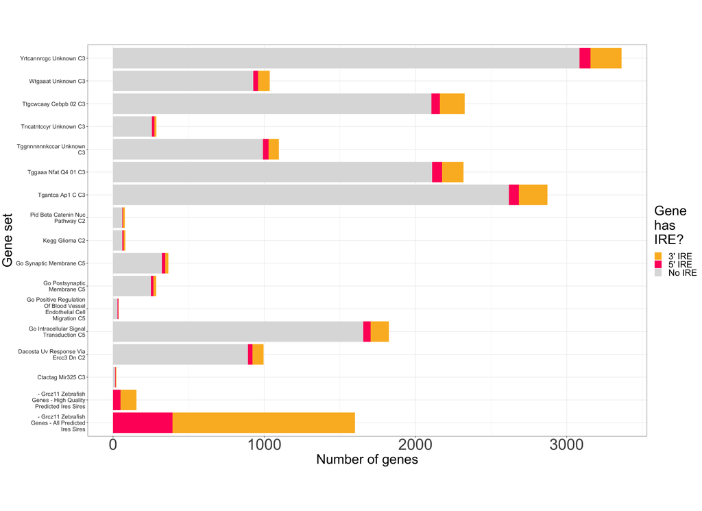

```r
overlapPlot <- overlapDf %>% ggplot(aes(x = str_to_title(stringr::str_wrap(geneset, 23)),
                     y = value,
                     fill = variable)) +
  geom_col() +
  theme(aspect.ratio = 0.7,
        axis.text.x =  element_text(size= 35),
        axis.title.x = element_text(size= 30),
        axis.title.y = element_text(size = 30),
        legend.text = element_text(size = 20),
        legend.title = element_text(size=30),
        axis.text.y = element_text(color = "grey20", size = 13)) +
  coord_flip() +  # Axis labels too long to be readable so this helps.
  scale_fill_manual(values=c("#FBB829", "#FF0066", "#dddddd"), labels =c("3' IRE", "5' IRE", "No IRE")) +
  labs(y = "Number of genes", x = "Gene set", fill = "Gene\nhas\nIRE?")
overlapPlot
```

```r
export::graph2ppt(overlapPlot, here("R","GSEA","fig","overlapPlot"))
```

## Export results

```r
gs %>% saveRDS(here("R","GSEA","results","gs.rds"))
gs %>% ungroup() %>% write.xlsx(here("R","GSEA","results","gs.xlsx"))

# Export significant genesets / of interest
gs %>%ungroup %>%
  arrange(fisher_p) %>%
  dplyr::filter(fdr < 0.1 | fdr_3 < 0.1 | fdr_5 < 0.1) %>%
  dplyr::filter(obs_greater_than_exp_allIRE == TRUE | obs_greater_than_exp_ire3 == TRUE | obs_greater_than_exp_ire5 == TRUE) %>%
  dplyr::select(geneset, source, n, n_with_ire3, n_with_ire5, n_without_ire, contains("fisher_p"), contains("fdr")) %>%
  write.xlsx(here("R","GSEA","results","gs_topRanked.xlsx"))
```

## TODO

- [x] Fisher’s test separately on 3’ IRE genes and 5’ IRE genes.
- [x] Stacked bar chart to indicate overlap of the top ~20 genesets with predicted IRE genes.
- [ ] Repeat this but with human / mouse IREs and their genesets to do a cross-species comparison.
- [x] Add in calculation of Expected and Observed IRE gene values and filter significant results to have Observed > Expected.